# 2-Gráficas dirigidas

Teresa Ortiz

**Repaso rápido**

**1. ¿Cuál es el valor de $\sum_l p(l|g)$?**

1. 1
2. p(l)
3. p(g)
4. No hay suficiente información.

**2. ¿Cuál es el valor de $\sum_i p(i, d)$?**

1. p(i|d)
2. p(i)
3. p(d|i)
4. p(d)

Una gráfica dirigida ${\mathcal G}$ es un conjunto de vértices junto con un subconjunto de aristas dirigidas (pares ordenados de vértices). En nuestro caso, cada vértice corresponde a una variable aleatoria, y cada arista dirigida representa una asociación probabilística entre las variables (vértices) que conecta. Nos interesan en particular las **gráficas dirigidas acíclicas** (GADs), estas son aquellas que no tienen caminos dirigidos partiendo de un vértice y regresando al mismo (ciclos).

**Ejemplo.**

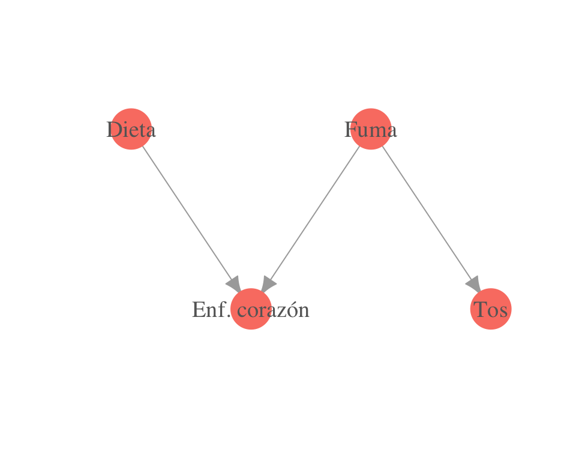

```r
library(igraph)
gr <- graph(c(1, 2, 3, 2, 3, 4))
plot(gr,
  vertex.label = c('Dieta', 'Enf. corazón', 'Fuma', 'Tos'),
  layout = matrix(c(0, 0.5, 2, 0, 4, 0.5, 6, 0), byrow = TRUE, ncol = 2),
  vertex.size = 23, vertex.color = 'salmon', vertex.label.cex = 1.2,
  vertex.label.color = 'gray40', vertex.frame.color = NA, asp = 0.5,
  edge.arrow.size = 1)
```

Nos interesan estas gráficas por lo que pueden representar acerca de la estructura de la distribución conjunta de las variables. Recordemos que la distribución conjunta es el modelo completo del fenómeno, a partir de la cual podemos contestar cualquier pregunta de inferencia, asociación, independencia, etc.

En las siguientes secciones explicaremos dos enfoques para interpretar una gráfica dirigida probabilísticamente (en términos de la distribición conjunta).

- Por una parte la gráfica define un esqueleto que sirve para representar de manera compacta una distribución de dimensión alta, esto es: En lugar de codificar la probabilidad de todos los posibles valores de las variables en nuestro dominio, podemos separar la distribución en factores más chicos, cada uno sobre un conjunto de posibilidades mucho más chico. Una vez que definimos los factores podemos definir la distribución conjunta como el producto de los factores.
- La segunda perspectiva es que la gráfica es una representación compacta de un conjunto de independencias que se sostienen en la distribución (la distribución que codifica nuestras creencias de una situación particular).

### Probabilidad conjunta y factorizaciones

Siempre es posible representar a una distribución conjunta como un producto de condicionales de una sola variable. Dado un ordenamiento $X_1,X_2,\ldots, X_k$, podemos escribir (por la regla del producto) $p(x_1,\ldots, x_k)=p(x_1)p(x_2|x_1)p(x_3|x_1,x_2)\cdots p(x_k|x_1,\ldots, x_{k-1}).$

Por ejemplo, si tenemos tres variables $X_1,X_2,X_3$ podemos usar la regla del producto para obtener

$p(x_1,x_2,x_3)= p(x_1)p(x_2|x_1)p(x_3|x_1,x_2),$

también podemos ordenar las variables de manera distinta y escribir:

$p(x_1,x_2,x_3)= p(x_3)p(x_1|x_3)p(x_2|x_1,x_3).$

Estas son representaciones válidas para la conjunta de $X_1,X_2,X_3$. Para modelar $X_1,X_2,X_3$ podríamos entonces estimar primero la marginal de $X_3$, después entender la condicional de $X_1$ dada $X_3$ y finalmente la condicional de $X_2$ dado $X_1$ y $X_3$. Algunas representaciones son más fáciles para trabajar, calcular y entender que otras.

Otro caso en que la factorización que escogemos es importante, es cuando existen independencias condicionales, la factorización puede resultar en un modelo más compacto o más conveniente.

$p(x_1,x_2,x_3)= p(x_3)p(x_1)p(x_2|x_1,x_3),$

y finalmente

$p(x_1,x_2,x_3)=p(x_3)p(x_1)p(x_2|x_3)$

el cual es un modelo considerablemente más simple que el original pues incluye dos marginales y sólo es necesario modelar cómo depende $x_2$ de $x_3$. Esto lo expresamos en el siguiente resultado:

Una factorización de la conjunta puede ser entendida como una parametrización particular de la conjunta a través de sus distribuciones condicionales.

**Ejemplo.** Supongamos la factorización $p(x,y)=p(x)p(y|x)$, y que $x$ y $y$ son variables binarias que toman los valores $0$ y $1$. La parametrización usual para $p(x,y)$ está dada por $p_{00},p_{01},p_{10},p_{11}$ donde $p(x,y)=p_{xy}$ y $p_{00} +p_{01}+p_{10}+p_{11}=1$ (3 parámetros en total). De esta forma tenemos que especificar, por ejemplo, los parámetros $p_{00},p_{01},p_{10}$.

Por otra parte, la factorización sugiere los parámetros $p_0,p_{0|1},p_{0|0},$ donde $p_0=p(x=0)$, $p_{0|1}=p(y=0|x=1)$ y $p_{0|0}=p(y=0|x=1)$. Los otros parámetros están dados por $p_1=1-p_0$, $p_{1|0}=1-p_{0|0}$ y $p_{1|1}=1-p_{0|1}$.

Nótese que la idea general es

1. Usar la regla de la cadena, lo que siempre nos da una expresión válida para la conjunta, y en la cual aparece la condicional de cada variable una sola vez para una ordenamiento adecuado de las variables.
2. Simplificar la expresión obtenida usando las independencias condicionales que suponemos.
3. Hacer los cálculos/inferencia, etc. usando la parametrización de condicionales.

### Factorizaciones de la conjunta y gráficas dirigidas.

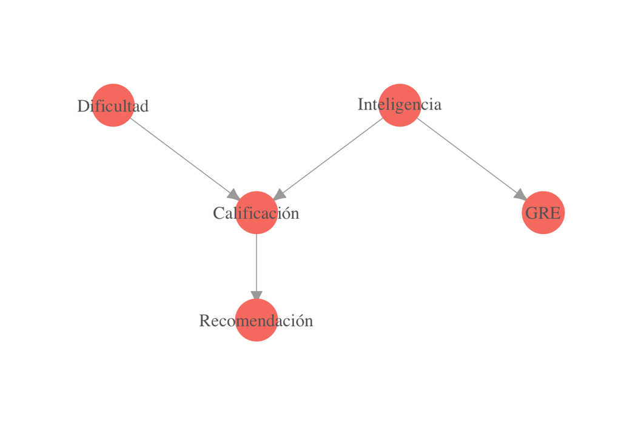

3. ¿Qué factorización crees que es apropiada para la distribución conjunta $p(d, i, c, g, r)$?
1. $p(d)p(i)p(c|i)p(c|d)$
2. $p(d)p(i)p(c|i,d)p(g|i)p(r|c)$
3. $p(d)p(i)p(c)p(g)p(r)$
4. $p(d|c)p(i|c,g)p(c|r)p(g)p(r)$
5. Ninguna de las anteriores.

En primer lugar, las _gráficas dirigidas acíclicas asociadas a una distribución conjunta dan una factorización particular $p$ para la conjunta.

Sea ${\mathcal G}$ una gráfica dirigida con vértices $X_1,X_2,...,X_k$, denotamos por $Pa(x_i)$ a todos los padres de $X_i$ en ${\mathcal G}$.

Sea $p$ una distribución conjunta para $X_1,X_2,\ldots, X_k$. Decimos que ${\mathcal G}$ **representa** a $p$ cuando la conjunta se factoriza como $p(x_1,x_2,\ldots, x_n)=\prod_{i=1}^k p(x_i|Pa(x_i)).$

El conjunto de distribuciones que son representadas por ${\mathcal G}$ lo denotamos por $M({\mathcal G})$ (llamadas distribuciones markovianas con respecto a $\mathcal G$).

**Nota.** La factorización del lado derecho del resultado $p(x_1,x_2,\ldots, x_n)=\prod_{i=1}^k p(x_i|Pa(x_i))$ siempre es una distribución de probabilidad. Por ejemplo, si consideramos la siguiente factorización de $p(x,u,d,f,e,y,t)$:

$p(x)p(u)p(d)p(f|d)p(e|f)p(y|f)p(t|d,u).$

Veremos que es una distribución de probabilidad como sigue: en primer lugar, este producto es no negativo, pues todas son distribuciones condicionales. Basta demostrar que si sumamos sobre todos los posibles valores de $x,u,d,f,e,y,t$, entonces esta expresión suma 1: $\sum_{x,u,d,f,e,y,t}p(x)p(u)p(d)p(f|d)p(e|f)p(y|f)p(t|d,u)$ $\left (\sum_{u,d,f,e,y,t}p(u)p(d)p(f|d)p(y|f)p(t|d,u)\right)\left(\sum_{x}p(x)\right)$ $\sum_{u,d,f,t}\left \{ p(u)p(d)p(f|d)p(t|d,u)\sum_y p(y|f)\sum_e p(e|f) \right\}$ $\sum_{u,d,f,t}p(u)p(d)p(f|d)p(t|d,u)$ $\sum_{u,d,t}\left \{ p(u)p(d)p(t|d,u)\sum_f p(f|d)\right \}$ $\sum_{u,d,t}p(u)p(d)p(t|d,u)$ $\sum_{u,d}p(u)p(d)$ $\sum_{d}p(d)\sum_u p(u)=1$

**Discusión.** Ordenamiento topológico de vértices en un gráfica dirigida acíclica.

En este último ejemplo vimos que el cálculo de la suma total se hace *empujando* primero dentro de la suma los índices de las variables que no tienen descendientes (o que no aparecen como condicionadoras), y trabajando hacia arriba. En términos de la gráfica, trabajamos de los *últimos vértices* hasta los *primeros*.

De hecho, una GAD siempre da un ordenamiento (topológico) de los vértices, módulo variables que están al mismo *nivel*. Por ejemplo, en la gráfica de la figura anterior, los ordenamientos son $D,I,C,G,R$ o $I,D,C,G,R$. ¿Qué ordenamiento da la siguiente gráfica?

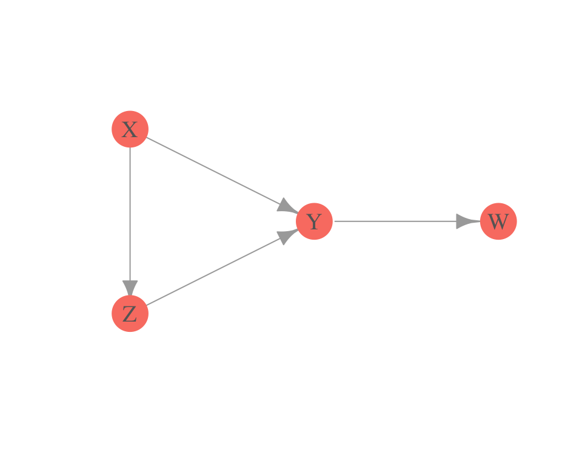

```r
 gr <- graph(c(1, 2, 1, 3, 3, 2, 2, 4))
 plot(gr,
  vertex.label=c('X','Y','Z','W'),
  layout = matrix(c(0, 0.5, 0.5, 0, 0, -0.5, 1, 0), byrow = TRUE, ncol = 2),
  vertex.size = 20, vertex.color = 'salmon', vertex.label.cex = 1.2,
  vertex.label.color = 'gray40', vertex.frame.color = NA, asp = 0.5,
  edge.arrow.size = 1)
```

**Ejemplo: Gráficas cíclicas.** Cuando hay ciclos en una gráfica, no hay una manera clara de entender qué factorización produce. Por ejemplo, si tenemos tres variables $X$, $Y$,$Z$ asociados con un ciclo $X\rightarrow Y\rightarrow Z\rightarrow X$, esto quizá sugiere una factorización $p(y|x)p(z|y)p(x|z)$. Pero se puede ver que esta expresión en general no es una distribución de probabilidad.

```r
library(dplyr)
# x: inteligencia, y: examen, z: trabajo
# y|x
mar_1 <- expand.grid(x = c("i_0", "i_1"), y = c("e_0", "e_1"))
mar_1$p1 <- c(0.95, 0.2, 0.05, 0.8)
# z|y
mar_2 <- expand.grid(y = c("e_0", "e_1"), z = c("t_0", "t_1"))
mar_2$p2 <- c(0.8, 0.4, 0.2, 0.6)
# x|z
mar_3 <- expand.grid(z = c("t_0", "t_1"), x = c("i_0", "i_1"))
mar_3$p3 <- c(0.8, 0.4, 0.2, 0.6)

tab_1 <- inner_join(mar_1, mar_2)
tab_2 <- inner_join(tab_1, mar_3)
tab_2$p <- tab_2$p1 * tab_2$p2 * tab_2$p3
sum(tab_2$p)
```

```
## [1] 1.12
```

En el ejemplo anterior vemos que $p(y|x)p(z|y)p(x|z)$ no suma uno. Por otra parte $p(x)p(y|x)p(z|y,x)$ si suma uno:

```r
# x: inteligencia, y: examen, z: trabajo
# x
mar_1 <- data.frame(x = c("i_0", "i_1"), p1 = c(0.6, 0.4))
# y|x
mar_2 <- expand.grid(x = c("i_0", "i_1"), y = c("e_0", "e_1"))
mar_2$p2 <- c(0.95, 0.2, 0.05, 0.8)
# z|x,y
mar_3 <- expand.grid(y = c("e_0", "e_1"), x = c("i_0", "i_1"),
                     z = c("t_0", "t_1"))
mar_3$p3 <- c(0.8, 0.6, 0.5, 0.1, 0.2, 0.4, 0.5, 0.9)

tab_1 <- inner_join(mar_1, mar_2)
tab_2 <- inner_join(tab_1, mar_3)
tab_2$p <- tab_2$p1 * tab_2$p2 * tab_2$p3
sum(tab_2$p)
```

```
## [1] 1
```

### Redes bayesianas

Ahora podemos definir *red bayesiana*:

Una **red bayesiana** es una gráfica GAD ${\mathcal G}$ junto con una distribución de probabilidad particular que se factoriza sobre $G$.

Dado que $p$ se factoriza sobre $\mathcal G$, podemos usar la factorización para evitar dar explícitamente la conjunta sobre todas las posibles combinaciones de las variables. Es decir, podemos usar la parametrización dada por la factorización en condicionales.

**Ejemplo.** Sea ${\mathcal G}$ la siguiente gráfica

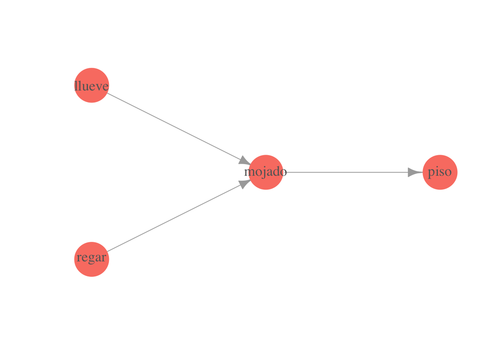

```r
library(igraph)
gr <- graph( c(1,2,3,2,2,4)  )
plot(gr,
  vertex.label=c('llueve', 'mojado', 'regar', 'piso'),
  layout = matrix(c(0, 1, 1, 0, 0, -1, 2, 0), byrow = TRUE, ncol = 2),
  vertex.size = 20, vertex.color = 'salmon', vertex.label.cex = 1.2,
  vertex.label.color = 'gray40', vertex.frame.color = NA, asp = 0.5,
  edge.arrow.size = 1)
```

La conjunta $p(m,l,r,z)$ ($z$ es piso resbaloso) se factoriza como $p(l)p(r)p(m|l,r)p(z|m)$

En este ejemplo construiremos la red como si fuéramos los expertos. Esta es una manera de construir redes que ha resultado útil y exitosa en varias áreas (por ejemplo diagnóstico).

De forma que podemos construir una red bayesiana simplemente dando los valores de cada factor. En nuestro ejemplo, empezamos por las marginales de $l$ y $r$:

```r
llueve <- c('No', 'Sí')
p_llueve <- data.frame(llueve = factor(llueve, levels= c("No", "Sí")),
  prob_l = c(0.9, 0.1))
p_llueve
```

```
##   llueve prob_l
## 1     No    0.9
## 2     Sí    0.1
```

```r
regar <- c('Apagado', 'Prendido')
p_regar <- data.frame(regar = factor(regar, levels = c('Apagado', 'Prendido')),
  prob_r = c(0.7, 0.3))
p_regar
```

```
##      regar prob_r
## 1  Apagado    0.7
## 2 Prendido    0.3
```

Ahora establecemos la condicional de mojado dado lluvia y regar:

```r
mojado <- c('Mojado','Seco')
# los niveles son todas las combinaciones de los valores de las variables
niveles <- expand.grid(llueve = llueve, regar = regar, mojado = mojado)
# mojado|lluve,regar
p_mojado_lr <- data.frame(niveles, prob_m = NA)
p_mojado_lr$prob_m[1:4] <- c(0.02, 0.6, 0.7, 0.9)
p_mojado_lr$prob_m[5:8]<- 1 - p_mojado_lr$prob_m[1:4]
p_mojado_lr
```

```
##   llueve    regar mojado prob_m
## 1     No  Apagado Mojado   0.02
## 2     Sí  Apagado Mojado   0.60
## 3     No Prendido Mojado   0.70
## 4     Sí Prendido Mojado   0.90
## 5     No  Apagado   Seco   0.98
## 6     Sí  Apagado   Seco   0.40
## 7     No Prendido   Seco   0.30
## 8     Sí Prendido   Seco   0.10
```

Y finalmente la condicional de piso resbaloso dado piso mojado:

```r
p_piso_mojado <- data.frame(expand.grid(
  piso = c('Muy.resbaladizo', 'Resbaladizo', 'Normal'),
  mojado=c('Mojado','Seco')))
p_piso_mojado
```

```
##              piso mojado
## 1 Muy.resbaladizo Mojado
## 2     Resbaladizo Mojado
## 3          Normal Mojado
## 4 Muy.resbaladizo   Seco
## 5     Resbaladizo   Seco
## 6          Normal   Seco
```

```r
p_piso_mojado$prob_p <- c(0.3, 0.6, 0.1, 0.02, 0.3, 0.68)
p_piso_mojado
```

```
##              piso mojado prob_p
## 1 Muy.resbaladizo Mojado   0.30
## 2     Resbaladizo Mojado   0.60
## 3          Normal Mojado   0.10
## 4 Muy.resbaladizo   Seco   0.02
## 5     Resbaladizo   Seco   0.30
## 6          Normal   Seco   0.68
```

Con esta información podemos calcular la conjunta. En este caso, como el problema es relativamente chico, podemos hacerlo explícitamente para todos los niveles:

```r
library(dplyr)
p_1 <- inner_join(p_piso_mojado, p_mojado_lr)
p_2 <- inner_join(p_1, p_llueve)
p_conj <- inner_join(p_2, p_regar)
p_conj$prob <- p_conj$prob_p * p_conj$prob_m * p_conj$prob_l * p_conj$prob_r
p_conj
```

```
##               piso mojado prob_p llueve    regar prob_m prob_l prob_r
## 1  Muy.resbaladizo Mojado   0.30     No  Apagado   0.02    0.9    0.7
## 2  Muy.resbaladizo Mojado   0.30     Sí  Apagado   0.60    0.1    0.7
## 3  Muy.resbaladizo Mojado   0.30     No Prendido   0.70    0.9    0.3
## 4  Muy.resbaladizo Mojado   0.30     Sí Prendido   0.90    0.1    0.3
## 5      Resbaladizo Mojado   0.60     No  Apagado   0.02    0.9    0.7
## 6      Resbaladizo Mojado   0.60     Sí  Apagado   0.60    0.1    0.7
## 7      Resbaladizo Mojado   0.60     No Prendido   0.70    0.9    0.3
## 8      Resbaladizo Mojado   0.60     Sí Prendido   0.90    0.1    0.3
## 9           Normal Mojado   0.10     No  Apagado   0.02    0.9    0.7
## 10          Normal Mojado   0.10     Sí  Apagado   0.60    0.1    0.7
## 11          Normal Mojado   0.10     No Prendido   0.70    0.9    0.3
## 12          Normal Mojado   0.10     Sí Prendido   0.90    0.1    0.3
## 13 Muy.resbaladizo   Seco   0.02     No  Apagado   0.98    0.9    0.7
## 14 Muy.resbaladizo   Seco   0.02     Sí  Apagado   0.40    0.1    0.7
```

[output cut: 35 more lines]

```r
sum(p_conj$prob)
```

```
## [1] 1
```

Usamos el paquete **bnlearn** para construir el objeto que corresponde a esta red bayesiana:

```r
library(bnlearn)
```

```r
# nodos
graf_jardin <- empty.graph(c('llueve', 'regar', 'mojado', 'piso'))
# arcos
arcs(graf_jardin) <- matrix(c('llueve', 'mojado', 'regar', 'mojado', 'mojado',
  'piso'), ncol = 2, byrow = T)
node.ordering(graf_jardin)
```

```
## [1] "llueve" "regar"  "mojado" "piso"
```

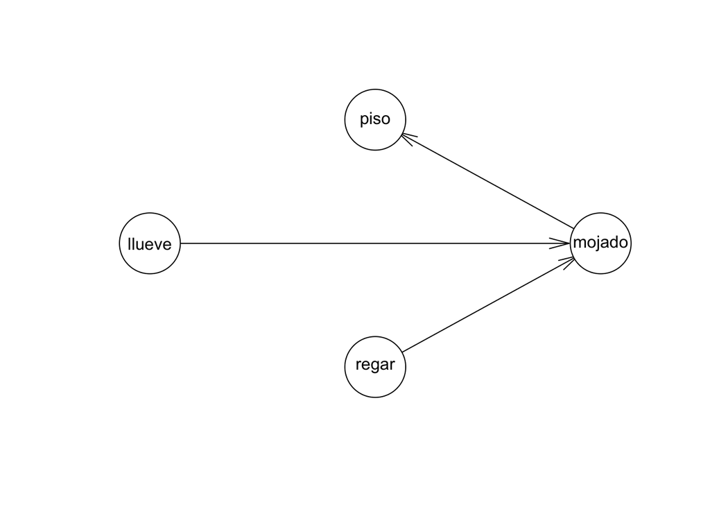

```r
plot(graf_jardin)
```

```r
modelo_jardin <- bn.fit(graf_jardin,
  data = data.frame(p_conj[, c('llueve', 'regar', 'mojado', 'piso')]))
```

Y este es el objeto que representa nuestra red (aunque falta corregir las probabilidades):

```r
str(modelo_jardin)
```

```
## List of 4
##  $ llueve:List of 4
##   ..$ node    : chr "llueve"
##   ..$ parents : chr(0)
##   ..$ children: chr "mojado"
##   ..$ prob    : table [1:2(1d)] 0.5 0.5
##   .. ..- attr(*, "dimnames")=List of 1
##   .. .. ..$ : chr [1:2] "No" "Sí"
##   ..- attr(*, "class")= chr "bn.fit.dnode"
##  $ regar :List of 4
##   ..$ node    : chr "regar"
##   ..$ parents : chr(0)
##   ..$ children: chr "mojado"
##   ..$ prob    : table [1:2(1d)] 0.5 0.5
##   .. ..- attr(*, "dimnames")=List of 1
##   .. .. ..$ : chr [1:2] "Apagado" "Prendido"
##   ..- attr(*, "class")= chr "bn.fit.dnode"
##  $ mojado:List of 4
##   ..$ node    : chr "mojado"
##   ..$ parents : chr [1:2] "llueve" "regar"
##   ..$ children: chr "piso"
##   ..$ prob    : table [1:2, 1:2, 1:2] 0.5 0.5 0.5 0.5 0.5 0.5 0.5 0.5
##   .. ..- attr(*, "dimnames")=List of 3
##   .. .. ..$ mojado: chr [1:2] "Mojado" "Seco"
##   .. .. ..$ llueve: chr [1:2] "No" "Sí"
##   .. .. ..$ regar : chr [1:2] "Apagado" "Prendido"
##   ..- attr(*, "class")= chr "bn.fit.dnode"
##  $ piso  :List of 4
##   ..$ node    : chr "piso"
##   ..$ parents : chr "mojado"
##   ..$ children: chr(0)
##   ..$ prob    : table [1:3, 1:2] 0.333 0.333 0.333 0.333 0.333 ...
##   .. ..- attr(*, "dimnames")=List of 2
##   .. .. ..$ piso  : chr [1:3] "Muy.resbaladizo" "Resbaladizo" "Normal"
##   .. .. ..$ mojado: chr [1:2] "Mojado" "Seco"
##   ..- attr(*, "class")= chr "bn.fit.dnode"
##  - attr(*, "class")= chr [1:2] "bn.fit" "bn.fit.dnet"
```

Ahora pondremos las probabilidades condicionales correctas (también llamados modelos locales):

```r
tab_1 <- table(p_conj$llueve)
tab_1[c(1, 2)] <- p_llueve[, 2]
tab_1
```

```
##
##  No  Sí
## 0.9 0.1
```

```r
modelo_jardin$llueve <- tab_1

tab_2 <- table(p_conj$regar)
tab_2[c(1,2)] <- p_regar[,2]
tab_2
```

```
##
##  Apagado Prendido
##      0.7      0.3
```

```r
modelo_jardin$regar <- tab_2

tab_3 <- xtabs(prob_m ~ mojado + llueve + regar, data = p_mojado_lr)
tab_3
```

```
## , , regar = Apagado
##
##         llueve
## mojado     No   Sí
##   Mojado 0.02 0.60
##   Seco   0.98 0.40
##
## , , regar = Prendido
##
##         llueve
## mojado     No   Sí
##   Mojado 0.70 0.90
##   Seco   0.30 0.10
```

```r
modelo_jardin$mojado <- tab_3

tab_4 <- xtabs(prob_p ~ piso + mojado, data = p_piso_mojado)
tab_4
```

```
##                  mojado
## piso              Mojado Seco
##   Muy.resbaladizo   0.30 0.02
##   Resbaladizo       0.60 0.30
##   Normal            0.10 0.68
```

```r
modelo_jardin$piso <- tab_4

modelo_jardin
```

```
##
##   Bayesian network parameters
##
##   Parameters of node llueve (multinomial distribution)
##
## Conditional probability table:
##
##  No  Sí
## 0.9 0.1
##
##   Parameters of node regar (multinomial distribution)
##
## Conditional probability table:
##
##  Apagado Prendido
##      0.7      0.3
##
##   Parameters of node mojado (multinomial distribution)
##
## Conditional probability table:
##
## , , regar = Apagado
##
##         llueve
## mojado     No   Sí
##   Mojado 0.02 0.60
##   Seco   0.98 0.40
##
## , , regar = Prendido
##
##         llueve
## mojado     No   Sí
##   Mojado 0.70 0.90
##   Seco   0.30 0.10
##
##
##   Parameters of node piso (multinomial distribution)
##
## Conditional probability table:
##
##                  mojado
## piso              Mojado Seco
##   Muy.resbaladizo   0.30 0.02
##   Resbaladizo       0.60 0.30
##   Normal            0.10 0.68
```

Finalmente, para hacer inferencia en la red (es decir, calcular probabilidades dado cierto conocimiento), necesitamos usar un algoritmo eficiente (por ejemplo en [SAMIAM](http://reasoning.cs.ucla.edu/samiam/). Aquí usamos el paquete **gRain**. Los *query* que hacemos son la inferencia, pero también se llaman así en la literatura de modelos gráficos. En este caso, podemos examinar las marginales condicionales a toda la evidencia (información) que tenemos.

Por ejemplo, ¿cómo se ven las marginales cuando sabemos que el piso está muy resbaladizo?

```r
library(gRain)
comp_jardin <- compile(as.grain(modelo_jardin))
querygrain(comp_jardin)
```

```
## $llueve
## llueve
##  No  Sí
## 0.9 0.1
##
## $regar
## regar
##  Apagado Prendido
##      0.7      0.3
##
## $mojado
## mojado
## Mojado   Seco
## 0.2706 0.7294
##
## $piso
## piso
## Muy.resbaladizo     Resbaladizo          Normal
##        0.095768        0.381180        0.523052
```

```r
query_1 <- setEvidence(comp_jardin, nodes = c('piso'),
  states = c('Muy.resbaladizo'))
querygrain(query_1)
```

```
## $llueve
## llueve
##        No        Sí
## 0.7773787 0.2226213
##
## $regar
## regar
##   Apagado  Prendido
## 0.3058224 0.6941776
##
## $mojado
## mojado
##    Mojado      Seco
## 0.8476735 0.1523265
```

```r
query_2 <- setEvidence(comp_jardin, nodes = c('llueve'), states = c('Sí'))
querygrain(query_2)$regar
```

```
## regar
##  Apagado Prendido
##      0.7      0.3
```

```r
query_3 <- setEvidence(comp_jardin, nodes = c('llueve'), states = c('No'))
querygrain(query_2)$regar
```

```
## regar
##  Apagado Prendido
##      0.7      0.3
```

Y ahora vemos la dependencia entre llueve y regar si condicionamos a piso resbaladizo:

```r
query_4 <- setEvidence(comp_jardin, nodes = c('piso', 'regar'),
  states = c('Muy.resbaladizo', 'Apagado'))
querygrain(query_4)$llueve
```

```
## llueve
##        No        Sí
## 0.5506692 0.4493308
```

```r
query_5 <- setEvidence(comp_jardin, nodes=c('piso', 'regar'),
  states = c('Muy.resbaladizo','Prendido'))
querygrain(query_5)$llueve
```

```
## llueve
##        No        Sí
## 0.8772563 0.1227437
```

Construir esta red en samaiam, y repetir los queries.

### Independencia condicional y redes bayesianas

Ahora abordamos el segundo enfoque de las redes bayesianas. En este, leemos directamente independencias condicionales a partir de la estructura de la gráfica (es esencialmente equivalente al criterio de factorización).

**Independencias condicionales locales**

Una distribución de probabilidad $p\in M({\mathcal G})$ (es decir, se factoriza en $\mathcal G$) si y sólo si para toda variable $W$, $W$ es condicionalmente independiente de cualquier variable que no sea su padre o descendiente dados los padres $Pa(W)$. Es decir $W \bot Z|Pa(W)$ para cualquier $Z$ que no sea descendiente o padre de $W$. Otra manera de decir esto es que dados los padres, un nodo sólo puede transmitir información probabilística a sus descendientes y a ningún otro nodo.

Por ejemplo, en la siguiente gráfica, el nodo rojo, dado los nodos azules, es condicionalmente independiente de los nodos grises:

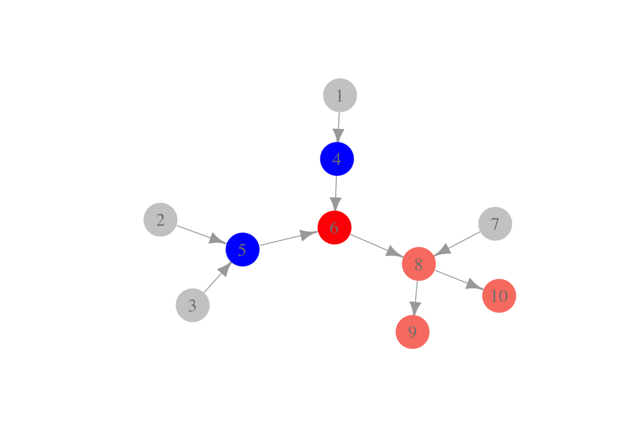

```r
gr <- graph(c(1, 4, 2, 5, 3, 5, 4, 6, 5, 6, 7, 8, 6, 8, 8, 9, 8, 10))
plot(gr,
  vertex.size = 20,
  vertex.color=c(rep('gray80', 3), rep('blue', 2), 'red', 'gray80', 'salmon',
    'salmon', 'salmon'),
  vertex.label.cex = 1.2, vertex.label.color = 'gray50', vertex.frame.color = NA,
  asp = 0.7, edge.arrow.size = 1)
```

#### Discusión de demostración.

Supongamos que las independencias locales se satisfacen según el enunciado anterior. Si tomamos las variables según el orden topológico de $\mathcal G$, dado por $X_1,\ldots, X_k$, entonces por la regla del producto:

$p(x)=\prod_{i=1}^k p(x_i|x_1,\ldots, x_{i-1}).$

Ahora, nótese que 1) para cada $X_i$, ninguna de las variables $X_1,\ldots, X_{i-1}$ es descendiente de $X_i$ y 2) que $Pa(X_i)$ está contenido en $X_1,\ldots, X_{i-1}$. Por lo tanto, por el supuesto de las independencias locales, vemos que $p(x_i|x_1,\ldots, x_{i-1})=p(x_i|Pa(x_i)),$ y así hemos demostrado que $p$ se factoriza en $\mathcal G$.

El otro sentido de la demostración es más difícil, veamos un ejemplo. En la siguiente gráfica, describimos una factorización para la conjunta de varias variables: inteligencia de un alumno, dificultad del curso, calificación obtenida en el curso, calificación obtenida en el examen GRE y si el alumno recibe o no una carta de recomendación de su profesor:

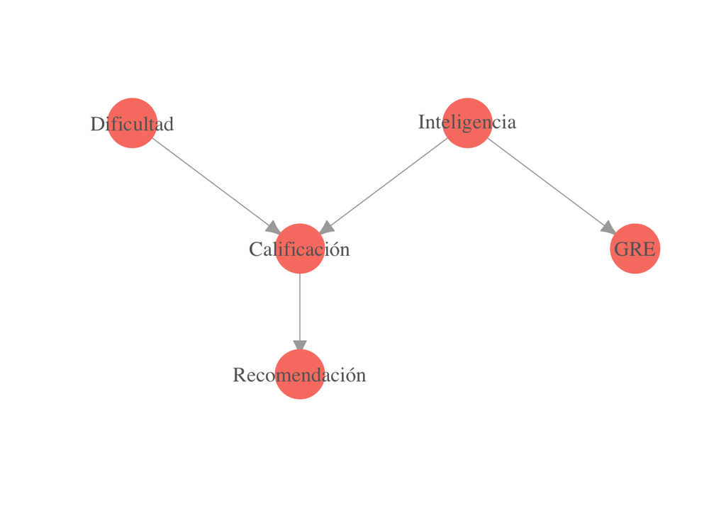

```r
library(igraph)
gr <- graph( c(1,3,2,3,2,4,3,5)  )
plot(gr,
  vertex.label=c('Dificultad','Inteligencia','Calificación','GRE',
                 'Recomendación'),
  layout = matrix(c(-1,2,1,2,0,1,2,1,0,0), byrow = TRUE, ncol = 2),
  vertex.size = 20, vertex.color = 'salmon', vertex.label.cex = 1.2,
  vertex.label.color = 'gray40', vertex.frame.color = NA, asp = 0.5,
  edge.arrow.size = 1)
```

La conjunta se factoriza como $p(i,d,c,g,r)=p(i)p(d)p(c|d,i)p(g|i)p(r|c).$

Queremos demostrar que dada la inteligencia, la calificación del GRE es condicionalmente independiente del resto de las variables (pues el resto no son ni padres ni descendientes de GRE), es decir, busamos demostrar que

$p(g|i,d,c,r)=p(g|i).$

Comenzamos por la factorización de arriba: $p(i,d,c,g,r)=p(i)p(d)p(c|d,i)p(g|i)p(r|c).$ Necesitamos calcular $p(g|i,d,c,r)=\frac{p(g,i,d,c,r)}{p(i,d,c,r)}.$ Así que comenzamos con la factorización y sumamos sobre $s$ para obtener $p(i,d,c,r)=\sum_g p(i)p(d)p(c|d,i)p(g|i)p(r|c),$ $p(i,d,c,r)=p(i)p(d)p(c|d,i)p(r|c),$ y dividiendo obtenemos que $p(g|i,d,c,r)=p(g|i),$ que era lo que queríamos demostrar.

De acuerdo a la gráfica, la calificación en el GRE es independiente de la dificultad una vez que conocemos la inteligencia, es decir $p(g | i, d) = p(g | i)$, veamos la factorización. Usando el teorema de Bayes podemos calcular la densidad condicional como,

$p(g|i,d) = \frac{p(g,i,d)}{p(i,d)}$

Por lo tanto, la densidad condicional es $p(g|i,d) = \frac{p(g,i,d)}{p(i,d)} = \frac{p(i)p(d)p(g|i)}{p(i)p(d)} = p(g|i),$ esto es, la calificación es independiente de la dificultad condicional a la inteligencia del alumno.

Repetir para $p(c|d,i)$.

Este último resultado explica cuáles son las independencias condicionales necesarias y suficientes para que una distribución se factorice según la gráfica ${\mathcal G}$. Ahora la pregunta que queremos resolver es: ¿hay otras independencias condicionales representadas en la gráfica? Buscamos independencias condicionales **no locales**. La respuesta es sí, pero necesitamos conceptos adicionales a los que hemos visto hasta ahora (d-separación).

**Ejemplo.** Antes de continuar, podemos ver un ejemplo de independencias no locales implicadas por la estructura gráfica. Si tenemos:

$X \rightarrow Y \rightarrow Z \rightarrow W$

es fácil ver que $X$ es independiente de $W$, dada $Y$, aunque esta independencia no es de la forma del resultado anterior, pues no estamos condicionando a los padres de ningún vértice.

### Flujo de información probabilística

En esta parte entenderemos primero como se comunica localmente la información probabilística a lo largo de los nodos cuando tenemos información acerca de alguno de ellos. Utilizaremos las factorizaciones implicadas por las gráficas asociadas.

**¿En cuáles de los siguientes casos información sobre $X$ puede potencialmente cambiar la distribución sobre $Y$?**

1. **Razonamiento causal**: $X\rightarrow Z \rightarrow Y$
- Si no tenemos información acerca de $Z$, $X$ y $Y$ pueden estar asociadas. En este caso tenemos $p(x,y,z)=p(x)p(z|x)p(y|z)$, de forma que, haciendo un cálculo simple: $p(x,y)= p(x) \sum_z p(y|z)p(z|x).$ Como siempre es cierto que $p(x,y)=p(x)p(y|x)$, tenemos $p(y|x)=\sum_z p(y|z)p(z|x),$ donde vemos que cuando cambia $x$, puede cambiar también $p(y|x)$.

  En el ejemplo $Edad \to Riesgo \to Accidente$, si alguien es más joven, entonces es más probable que sea arriesgado, y esto hace más probable que tenga un accidente.
- Si sabemos el valor de $Z$, sin embargo, $X$ no nos da información de $Y$. En este caso tenemos $p(x,y)=p(x)p(z|x)p(y|z)$, como $z$ está fija tenemos que $p(x,y)=p(x)h(x)g(y)$, donde $h$ y $g$ son funciones fijas. Como la conjunta se factoriza, $X$ y $Y$ son independientes dada $Z$.

  En nuestro ejemplo, si conociemos la aversión al riesgo, la edad del asegurado no da información adicional acerca de la probabilidad de tener un accidente.
2. **Razonamiento evidencial**: $Y\rightarrow Z \rightarrow X.$
- Si no sabemos acerca de $Z$, sí, por un argumento similar al del inciso anterior. Es un argumento de probabilidad inversa en $Edad \to Riesgo \to Accidente$. Si alguien tuvo un accidente, entonces es más probable que sea arriesgado, y por tanto es más probable que sea joven.
- Si sabemos el valor que toma $Z$, entonces $X$ no puede influenciar a $Y$, por un argumento similar.
3. **Razonamiento de causa común**: $X\leftarrow Z \rightarrow Y$.
- Sí, pues en este caso: $p(x,y,z)=p(z)p(y|z)p(x|z),$ Sumando sobre $z$ tenemos $p(x,y)=\sum_z p(y|z)p(x,z),$ así que $p(y|x)=\sum_z p(y|z)p(z|x).$

  En el ejemplo podríamos tener $Tiempo manejando \leftarrow Edad \rightarrow Riesgo$. Una persona que lleva mucha tiempo manejando es más probablemente mayor, lo cual hace más probable que sea aversa al riesgo.
- No. Si conocemos el valor de $Z$, entonces $X$ y $Y$ son condicionalmente independientes, pues $p(x,y,z)=p(z)p(y|z)p(x|z)$, donde vemos que una vez que está dada la $z$ $x$ y $y$ no interactuán (están en factores distintos).
4. **Razonamiento intercausal**: Colisionador o estructura-v: $X\rightarrow Z \leftarrow Y$.
- Si no tenemos información acerca de $Z$, **no**. Esto es porque tenemos $p(x,y,z)=p(x)p(y)p(z|x,y),$ de donde vemos que la conjunta de $X$ y $Y$ satisface $p(x,y)=p(x)p(y)$ (sumando sobre $z$).

  Podríamos tener que $Calidad de conductor \rightarrow Accidente \leftarrow Condicion de calle$. Que alguien vaya por una calle en mal estado no cambia las probabilidades de ser un mal conductor (en nuestro modelo).
- Si sabemos el valor de $Z$, **sí** conocimiento de $X$ puede cambiar probabilidades de $Y$. Como tenemos $p(x,y,z)=p(x)p(y)p(z|x,y),$ el término (z está fijo) $p(z|x,y)=h(x,y)$ puede incluir interacciones entre $x$ y $y$.

  En nuestro ejemplo, si sabemos que hubo un accidente, las condiciones de la calle si nos da información acerca de la calidad del conductor: por ejemplo, si la calle está en buen estado, se hace más probable que se trate de un conductor malo.

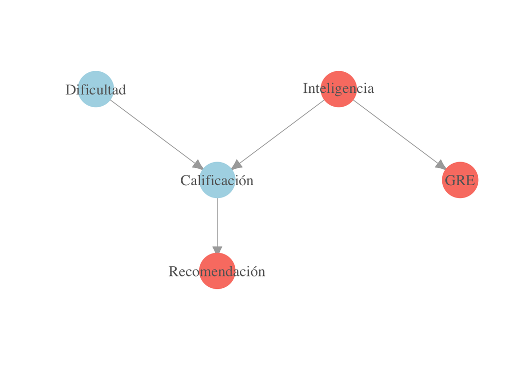

Si sabemos que la clase es difícil y que el estudiante obtuvo 6, ¿como cambia la probabilidad posterior de inteligencia alta? a) sube b) baja c) no cambia d) No se puede saber?

### Caminos: pelota de Bayes

Un camino (no dirigido) esta activo si una pelota de Bayes que viaja a través del camino NO se topa con un símbolo de bloqueo (->|). En los esquemas los nodos sombreados indican que se tiene información de esas variables (ya no son aleatorios).

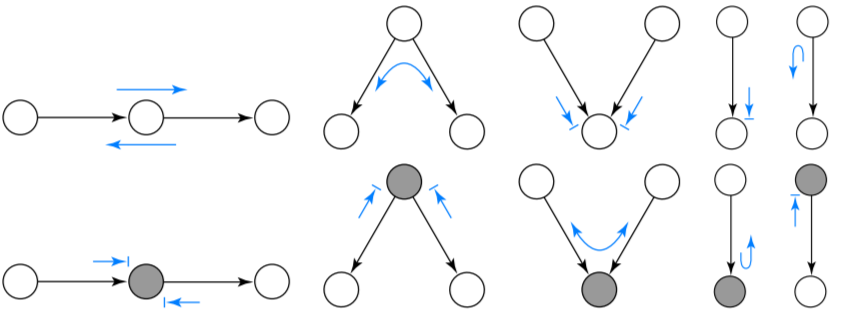

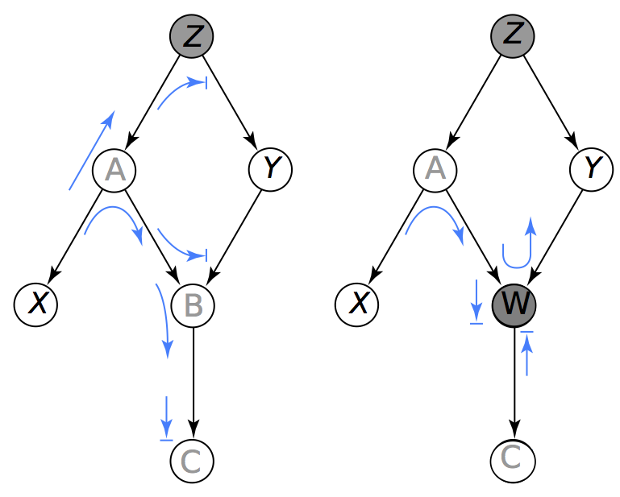

Utilizando la gráfica del lado derecho demuestra algebráicamente que dados $Z,W$, $X$ no es necesariamente independiente de $Y$.

## Flujo de probabilidad y d-Separación

De la discusión anterior, definimos **caminos activos** en una gráfica los que, dada cierta evidencia $Z$, pueden potencialmente transmitir información probabilística.

Sea $U$ un camino no dirigido en una gráfica ${\mathcal G}$. Decimos que el **camino es activo** dada evidencia $W$ si:

- Todos los colisionadores en el camino $U$ están o tienen un descendiente en $W$.
- Ningún otro vértice de el camino está en $W$.

Un caso adicional interesante es cuando los descendiente de un colisionador activan un camino.

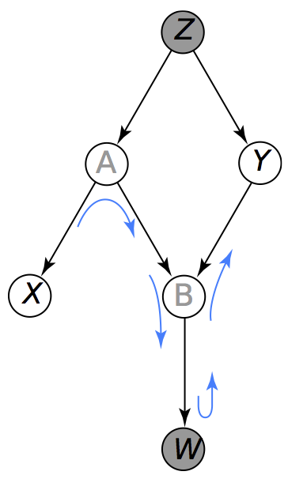

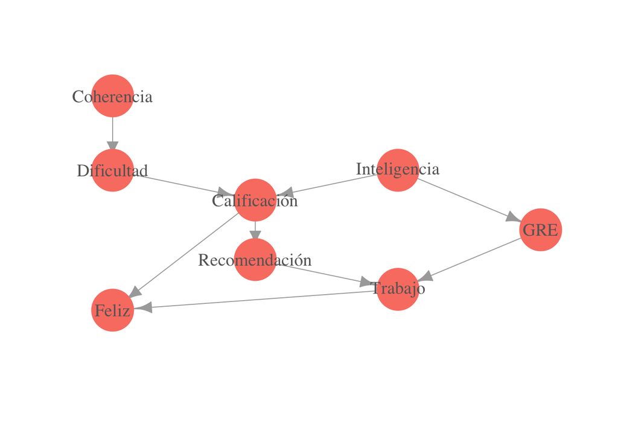

Volviendo al ejemplo anterior

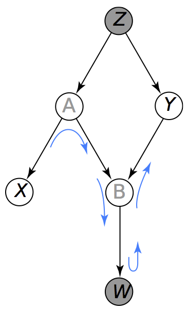

**Algebráicamente:** La distribución conjunta se factoriza como: $p(z,a,y,x,b,w)=p(z)p(a|z)p(y|z)p(x|a)p(b|a,y)p(w|b)$ Por lo que la marginal $p(x,y,w,z)$ se obtiene de la siguiente manera: $p(x,y,w,z) = \sum_a \sum_b p(z,a,y,x,b,w)$

$= \sum_a \sum_b p(z)p(a|z)p(y|z)p(x|a)p(b|a,y)p(w|b)$ $= p(z)p(y|z) \sum_a p(a|z)p(x|a) \sum_b p(b|a,y)p(w|b)$

Notamos que $X$ y $Y$ interactúan a través de $A$ y $B$, por lo que no es posible encontrar dos funciones $g$, $h$, tales que $p(x,y,w,z) \propto g(x,w,z) h(y,w,z)$ y concluímos que $X \not \perp Y | W$.

Sean $X$ y $Y$ vértices distintos y $W$ un conjunto de vértices que no contiene a $X$ o $Y$. Decimos que $X$ y $Y$ están **d-separados dada** $W$ si no existen caminos activos dada $W$ entre $X$ y $Y$.

Es decir, la $d$-separación desaparece cuando hay información condicionada en colisionadores o descendientes de colisionadores.

Este concepto de $d$-separación es precisamente el que funciona para encontrar todas las independencias condicionales:

Supongamos que $p$ se factoriza sobre $\mathcal G$. Sean $A$, $B$ y $C$ conjuntos disjuntos de vértices de ${\mathcal G}$. Si $A$ y $B$ están $d$-separados por $C$ entonces $A\bot B | C$ bajo $p$ .

#### Discusión

El resultado anterior no caracteriza la independencia condicional de una distribución $p$ por una razón simple, que podemos entender como sigue: si agregamos aristas a una gráfica ${\mathcal G}$ sobre la que se factoriza $p$, entonces $p$ se factoriza también sobre la nueva gráfica ${\mathcal G}'$. Esto reduce el número de independencias de $p$ que representa ${\mathcal G}$.

Un ejemplo trivial son dos variables aleatorias independientes $X$ y $Y$ bajo $p$. $p$ claramente se factoriza en $X\to Y$, pero de esta gráfica no se puede leer la independencia de $X$ y $Y$.

¿Qué es lo malo de esto? En primer lugar, si usamos ${\mathcal G}'$ en lugar de ${\mathcal G}$, no reducimos la complejidad del modelo al usar las independencias condicionales gráficas que desaparecen al agregar aristas. En segundo lugar, la independencia condicional no mostrada en la gráfica es más difícil de descubrir: tendríamos que ver directamente la conjunta particular de nuestro problema, en lugar de leerla directamente de la gráfica.

Finalmente, estos argumentos también sugieren que quisiéramos encontrar mapeos que no sólo sean *mínimos* (no se pueden eliminar aristas), sino también *perfectos* en el sentido de que representan exactamente las independencias condicionales. Veremos estos temas más adelante.

Algo que sí podemos establecer es cómo se comporta la familia de distribuciones que se factorizan sobre una gráfica $\mathcal G$:

Sea $\mathcal G$ una DAG. Si $X$ y $Y$ no están $d$-separadas en $\mathcal G$, entonces existe **alguna** distribución $q$ (que se factoriza sobre ${\mathcal G}$) tal que $X$ y $Y$ **no** son independientes bajo $q$.

Para que existan independencias que no están asociadas a $d$-separación los parámetros deben tomar valores paticulares. Este conjunto de valores es relativamente chico en el espacio de parámetros (son superficies), por lo tanto podemos hacer más fuerte este resultado:

Sea $\mathcal G$ una DAG. Excepto en un conjunto de “medida cero” en el espacio de distribuciones $M({\mathcal G})$ que se factorizan sobre $\mathcal G$, tenemos que $d$-separación es equivalente a independencia condicional. Es decir, $d$-separación caracteriza precisamente las independencias condicionales de cada $p\in M(\mathcal G)$, excepto para un conjunto relativamente chico de $p \in M({\mathcal G})$ .

### Equivalencia Markoviana

En esta parte trataremos el problema de la unicidad de la representación gráfica dada un conjunto de independencias condicionales. La respuesta corta es que las representaciones no son únicas, pues algunas flechas pueden reorientarse sin que haya cambios en términos de la conjunta representada.

Decimos que dos gráficas ${\mathcal G}_1$ y ${\mathcal G}_2$ son **Markov equivalentes** cuando el conjunto de independencias implicadas de ambas es el mismo. Otra manera de decir esto, es que ambas gráficas tienen exactamente la misma estructura de $d-$separación.

La equivalencia Markoviana limita nuestra capacidad de inferir la dirección de las flechas únicamente de las probabilidades, esto implica que dos gráficas Markov equivalentes no se pueden distinguir usando solamente una base de datos. Por ejemplo, en la siguiente gráfica, cambiar la dirección del arco que une $X_1$ y $X_2$ genera una gráfica Markov equivalente, esto es, la dirección del arco que une a $X_1$ y $X_2$ no se puede inferir de información probabilística.

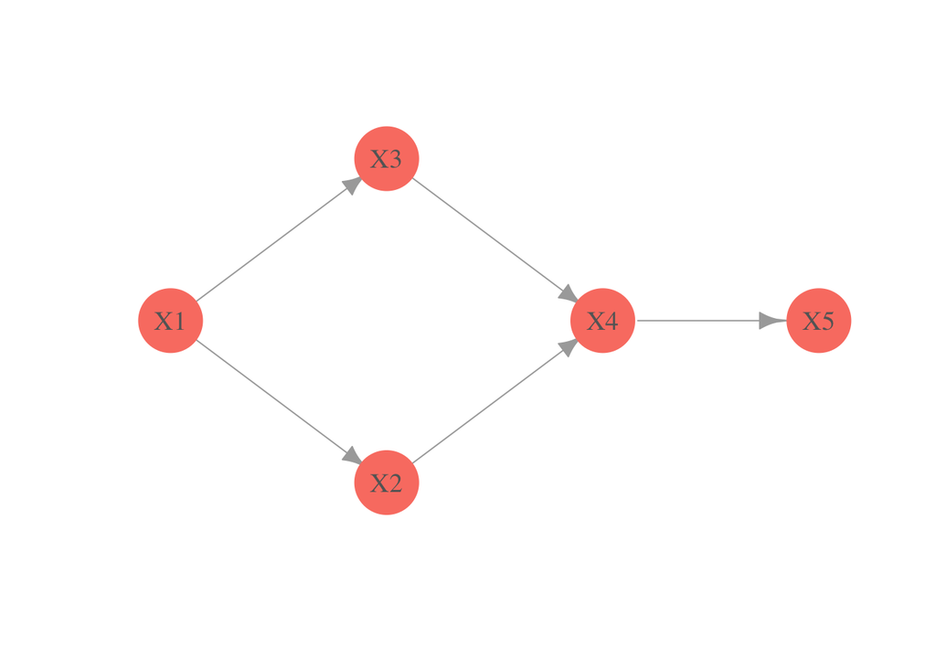

```r
library(igraph)
gr <- graph( c(1,2,1,3,2,4,3,4,4,5)  )
plot(gr, vertex.label=c('X1','X2','X3','X4','X5'),
  layout = matrix(c(-0.3,0,0,-0.3,0, 0.3,0.3,0,0.6,0), byrow = TRUE, ncol = 2),
  vertex.size = 20, vertex.color = 'salmon', vertex.label.cex = 1.2,
  vertex.label.color = 'gray40', vertex.frame.color = NA, asp = 0.5,
  edge.arrow.size = 1)
```

Decimos que un colisionador *no está protegido* cuando las variables que apuntan a la colisión no tienen vértice entre ellas. Definimos adicionalmente el *esqueleto* de una GAD como la versión no dirigida de $\mathcal G$. El siguiente resultado establece que la distribución sólo puede determinar determinar la dirección de las flechas en presencia de un colisionador no protegido:

Dos gráficas ${\mathcal G}_1$ y ${\mathcal G}_2$ son Markov equivalentes si y sólo si

- Sus esqueletos son iguales y
- ${\mathcal G}_1$ y ${\mathcal G}_2$ tienen los mismos colisionadores no protegidos.

Las equivalencias que señala este teorema son importantes. Por ejemplo, las gráficas $X\rightarrow Y \rightarrow Z$ y $X\leftarrow Y \leftarrow Z$ son equivalentes, lo que implica que representan a las mismas distribuciones condicionales. Solamente usando datos (o el modelo), **no podemos distinguir estas dos estructuras**, sin embargo, puede ser que tengamos información adicional para preferir una sobre otra (por ejemplo, si es una serie de tiempo).

Una estructura que sí podemos identificar de manera dirigida es el colisionador. El resto de las direcciones pueden establecerse por facilidad de interpretación o razones causales.

Regresando a la gráfica anterior, notamos que al revertir el sentido del arco que une a $X_1$ con $X_2$ no se crea ni se destruye ningun colisionador y por tanto la gráfica resultante del cambio de sentido es efectivamente Markov equivalente. Consideremos ahora los arcos dirigidos que unen a $X_2$ con $X_4$ y a $X_4$ con $X_5$, notamos que no hay manera de revertir la dirección de estos arcos si crear un nuevo colisionador, esto implica que algunas funciones de probabilidad $p$ restringen la dirección de éstas flechas en la gráfica.

En el siguiente ejemplo, mostramos la clase de equivalencia de una red de ejemplo. Ahí vemos cuáles son las aristas que se pueden orientar de distinta manera, y cuáles pertenecen a colisionadores en los cuales las direcciones están identificadas:

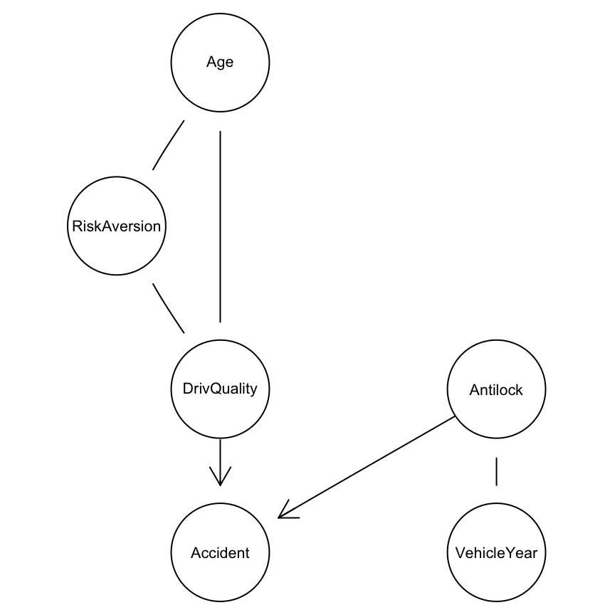

[figure not shown]

```r
library(bnlearn)
grafica.1 <- gs(insurance[c('Age', 'RiskAversion', 'Accident', 'DrivQuality',
  'Antilock', 'VehicleYear')], alpha = 0.01)
graphviz.plot(grafica.1)
```

¿Cuáles de las gráficas anteriores son Markov equivalentes?

1. 1 y 2
2. 1 y 3
3. 2 y 4
4. 2 y 4
5. Ninguna

### Resumen

- Dada una gráfica $G$ podemos encontrar las as independencias condicionales que establece, $I(G)$.
- Dada una distribución $p$ podemos encontrar las independencias que implica, $I(p)$ (en teoría).
- Las independencias condicionales definidas por la red bayesiana son un subconjunto de las independencias en $p$, esto es $I(G) \subset I(p)$.
- Equivalencia Markoviana se expresa como: $I(G) = I(G')$.

### Ejemlos

- [Repositorio de redes](http://www.cs.huji.ac.il/~galel/Repository/)
- [Universidad de Utrecht](http://bndg.cs.aau.dk/html/bayesian_networks.html)
- [Genie y Smile](https://dslpitt.org/genie/index.php/network-repository)
- [Librería de Norsys (Netica)](http://www.norsys.com/netlibrary/index.htm)
- [Casos de Hugin](http://www.hugin.com/case-stories)